# ggplot2

```r
library(dplyr)
library(ggplot2)
```

```r
library(dslabs)
data(murders)
```

1. 8.2 ggplot objects The first step in creating a ggplot2 graph is to define a ggplot object. We do this with the function ggplot, which initializes the graph.

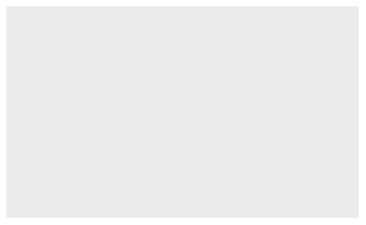

```r
murders %>% ggplot()
```

It renders a plot, in this case a blank slate since no geometry has been defined. The only style choice we see is a grey background.

What has happened above is that the object was created and, because it was not assigned, it was automatically evaluated.

1. 8.3 Geometries In ggplot2 we create graphs by adding layers. Layers can define geometries, compute summary statistics, define what scales to use, or even change styles. To add layers, we use the the symbol +. In general, a line of code will look like this: DATA %>% ggplot() + LAYER 1 + LAYER 2 + … + LAYER N Usually, the first added layer defines the geometry. We want to make a scatterplot. What geometry do we use?

1. 8.4 Aesthetic mappings Aesthetic mappings describe how properties of the data connect with features of the graph, such as distance along an axis, size or color. The aes function connects data with what we see on the graph by defining aesthetic mappings. and will be one of the functions you use most often when plotting. The outcome of the aes function is often used as the argument of a geometry function. This example produces a scatterplot of total murders versus population in millions:

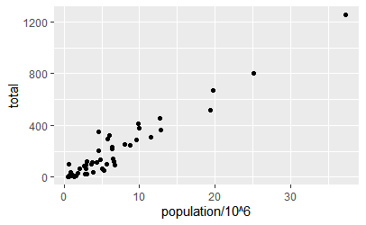

```r
murders %>% ggplot() +
  geom_point(aes(x = population/10^6, y = total))
```

The scale and labels are defined by default when adding this layer. Like dplyr functions, aes also uses the variable names from the object component: we can use population and total without having to call them as murders$population and murders$total. The behavior of recognizing the variables from the data component is quite specific to aes. With most functions, if you try to access the values of population or total outside of aes you receive an error.

1. 8.5 Layers A second layer in the plot we wish to make involves adding a label to each point to identify the state. The geom_label and geom_text functions permit us to add text to the plot with and without a rectangle behind the text respectively.

Because each point (each state in this case) has a label, we need an aesthetic mapping to make the connection between points and labels. By reading the help file, we learn that we supply the mapping between point and label through the label argument of aes. So the code looks like this:

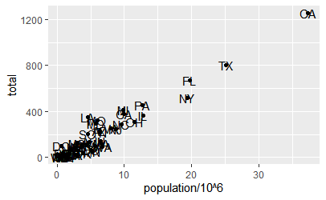

```r
murders %>% ggplot() +
  geom_point(aes(x = population/10^6, y = total)) +
  geom_text(aes(population/10^6, total, label = abb))
```

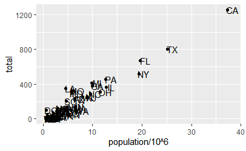

```r
p <- ggplot(data = murders)
p + geom_point(aes(population/10^6, total)) + geom_text(aes(population/10^6, total, label = abb), nudge_x=1)
```

1. 8.6 Global versus local aesthetic mappings In the previous line of code, we define the mapping aes(population/10^6, total) twice, once in each geometry. We can avoid this by using a global aesthetic mapping. We can do this when we define the blank slate ggplot object. If we define a mapping in ggplot, all the geometries that are added as layers will default to this mapping. We redefine p:

p <- murders %>% ggplot(aes(population/10^6, total, label = abb)) and then we can simply write the following code:

p + geom_point(size = 3) + geom_text(nudge_x = 1.5)

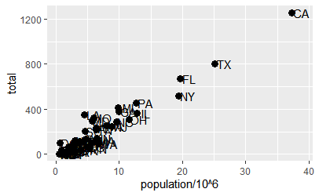

```r
p <- murders %>% ggplot(aes(population/10^6, total, label = abb))
p + geom_point(size=3) + geom_text(nudge_x = 1.5)
```

If necessary, we can override the global mapping by defining a new mapping within each layer. These local definitions override the global. Here is an example:

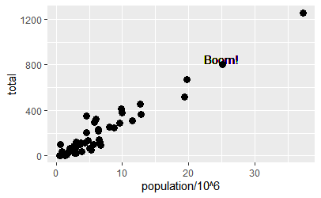

```r
p <- murders %>% ggplot(aes(population/10^6, total, label = abb))
p + geom_point(size = 3) + geom_text(aes(x=25, y=850, label = "Boom!"))
```

1. 8.7 Scales

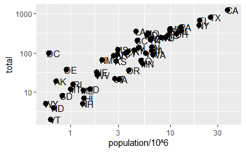

```r
p + geom_point(size = 3) +
  geom_text(nudge_x = 0.05) +
  scale_x_continuous(trans = "log10") +
  scale_y_continuous(trans = "log10")
```

1. 8.8 Labels and titles

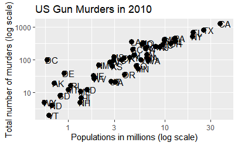

```r
p + geom_point(size = 3) +
  geom_text(nudge_x = 0.05) +
  scale_x_log10() +
  scale_y_log10() +
  xlab("Populations in millions (log scale)") +
  ylab("Total number of murders (log scale)") +
  ggtitle("US Gun Murders in 2010")
```

1. 8.9 Categories as colors Since the choice of color is determined by a feature of each observation, this is an aesthetic mapping. To map each point to a color, we need to use aes. We use the following code:

p + geom_point(aes(col=region), size = 3)

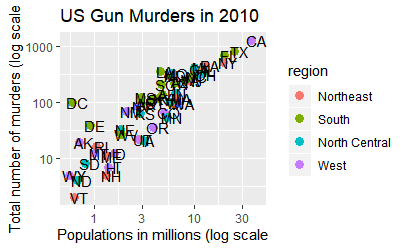

```r
p <- murders %>% ggplot(aes(population/10^6, total, label = abb))
p + geom_point(aes(col=region), size=3) + geom_text(nudge_x=0.05) +
  scale_x_log10() + scale_y_log10() +
  xlab("Populations in millions (log scale") +
  ylab("Total number of murders (log scale") +
  ggtitle("US Gun Murders in 2010")
```

1. 8.10 Annotation, shapes, and adjustments We often want to add shapes or annotation to figures that are not derived directly from the aesthetic mapping; examples include labels, boxes, shaded areas and lines.

Here we want to add a line that represents the average murder rate for the entire country.

To add a line we use the geom_abline function. ggplot2 uses ab in the name to remind us we are supplying the intercept (a) and slope (b). The default line has slope 1 and intercept 0 so we only have to define the intercept:

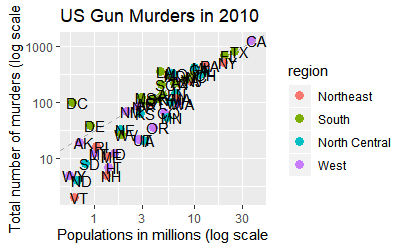

```r
r <- murders %>%
  summarize(rate = sum(total) /  sum(population) * 10^6) %>%
  pull(rate)

p <- murders %>% ggplot(aes(population/10^6, total, label = abb))
p + geom_point(aes(col=region), size=3) +
  geom_abline(intercept = log10(r), lty = 2, color = "darkgrey") +
  geom_text(nudge_x=0.05) +
  scale_x_log10() + scale_y_log10() +
  xlab("Populations in millions (log scale") +
  ylab("Total number of murders (log scale") +
  ggtitle("US Gun Murders in 2010")
```

1. 8.11 Add-on packages The power of ggplot2 is augmented further due to the availability of add-on packages. The remaining changes needed to put the finishing touches on our plot require the ggthemes and ggrepel packages.

The style of a ggplot2 graph can be changed using the theme functions. Several themes are included as part of the ggplot2 package. In fact, for most of the plots in this book, we use a function in the dslabs package that automatically sets a default theme: ds_theme_set()

The final difference has to do with the position of the labels. In our plot, some of the labels fall on top of each other. The add-on package ggrepel includes a geometry that adds labels while ensuring that they don’t fall on top of each other. We simply change geom_text with geom_text_repel.

```r
install.packages("ggthemes")
```

```r
install.packages("ggrepel")
```

```r
library(ggrepel)
```

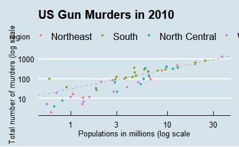

```r
library(ggthemes)

p <- murders %>% ggplot(aes(population/10^6, total, label = abb))
p + theme_economist() +
  geom_point(aes(col=region), size=1) +
  geom_abline(intercept = log10(r), lty = 2, color = "darkgrey") +
  geom_text_repel(nudge_x=0.05) +
  scale_x_log10() + scale_y_log10() +
  xlab("Populations in millions (log scale") +
  ylab("Total number of murders (log scale") +
  ggtitle("US Gun Murders in 2010")
```

1. 8.13 Quick plots with qplot This seems like too much code for such a simple plot. The qplot function sacrifices the flexibility provided by the ggplot approach, but allows us to generate a plot quickly.

qplot(x, y)

1. 8.14 Grids of plots There are often reasons to graph plots next to each other. The gridExtra package permits us to do that:

```r
install.packages("gridExtra")
```

```r
library(gridExtra)
p1 <- murders %>%
  mutate(rate = total/population*10^5) %>%
  filter(population < 2*10^6) %>%
  ggplot(aes(population/10^6, rate, label = abb)) +
  geom_text() +
  ggtitle("Small States")

p2 <- murders %>%
  mutate(rate = total/population*10^5) %>%
  filter(population > 10*10^6) %>%
  ggplot(aes(population/10^6, rate, label = abb)) +
  geom_text() +
  ggtitle("Large States")

grid.arrange(p1, p2, ncol = 2)
```

[output not shown]

1. 8.15 Exercises

```r
data("heights")
data("murders")
```

1. What is class of the object p?

```r
p <- murders %>% ggplot()
class(p)
```

```
[1] "gg"     "ggplot"
```

2. Print the object p defined in exercise one and describe what you see.

A. Nothing happens. B. A blank slate plot. <- answer C. A scatter plot. D. A histogram.

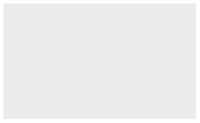

```r
print(p)
```

3. Using the pipe %>%, create an object p but this time associated with the heights dataset instead of the murders dataset.

```r
head(heights)
```

|  | sex | height |
| --- | --- | --- |
| 1 | Male | 75 |
| 2 | Male | 70 |
| 3 | Male | 68 |
| 4 | Male | 74 |
| 5 | Male | 61 |
| 6 | Female | 65 |

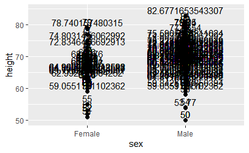

```r
p <- heights %>% ggplot(aes(sex, height, label=height))
p + geom_point(size=2) +
  geom_text(nudge_y=2)
```

```r
class(p)
```

```
[1] "gg"     "ggplot"
```

6. To create the scatter plot we add a layer with geom_point. The aesthetic mappings require us to define the x-axis and y-axis variables respectively. So the code looks like this:

murders %>% ggplot(aes(x = , y = )) + geom_point() except we have to define the two variables x and y. Fill this out with the correct variable names.

7. Note that if we don’t use argument names, we can obtain the same plot by making sure we enter the variable names in the right order like this:

murders %>% ggplot(aes(population, total)) + geom_point() Remake the plot but now with total in the x-axis and population in the y-axis.

8. If instead of points we want to add text, we can use the geom_text() or geom_label() geometries. The following code murders %>% ggplot(aes(population, total)) + geom_label() will give us the error message: Error: geom_label requires the following missing aesthetics: label

Why is this?

A. We need to map a character to each point through the label argument in aes. <- answer B. We need to let geom_label know what character to use in the plot. C. The geom_label geometry does not require x-axis and y-axis values. D. geom_label is not a ggplot2 command.

9. Rewrite the code above to abbreviation as the label through aes 9

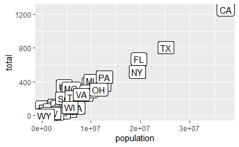

```r
murders %>% ggplot(aes(population, total, label=abb)) +
  geom_label()
```

10. Change the color of the labels through blue. How will we do this?

11. Rewrite the code above to make the labels blue.

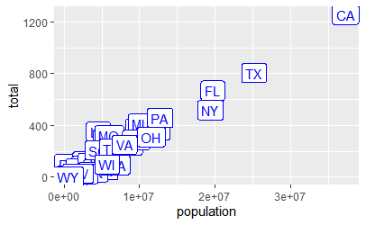

```r
murders %>% ggplot(aes(population, total, label=abb, )) +
  geom_label(color="blue")
```

13. Rewrite the code above to make the labels’ color be determined by the state’s region.

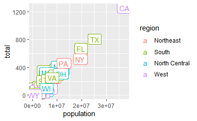

```r
murders %>% ggplot(aes(population, total, label=abb, col=region )) +
  geom_label()
```

14. Now we are going to change the x-axis to a log scale to account for the fact the distribution of population is skewed. Let’s start by define an object p holding the plot we have made up to now

```r
p <- murders %>%
  ggplot(aes(population, total, label = abb, color = region)) +
  geom_label() +
  scale_x_log10() +
  scale_y_log10()
```

15. Repeat the previous exercise but now change both axes to be in the log scale.
16. Now edit the code above to add the title “Gun murder data” to the plot. Hint: use the ggtitle function.

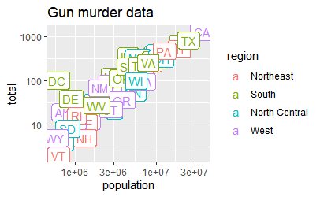

```r
p <- murders %>%
  ggplot(aes(population, total, label = abb, color = region)) +
  geom_label() +
  scale_x_log10() +
  scale_y_log10() +
  ggtitle("Gun murder data")

p
```